# Introdução à Ciência de Dados

Mestrado Profissional em Administração

Prof. Washington Santos da Silva

IFMG - Campus Formiga

8 de maio de 2025

## Diário de Bordo

**O que vimos até aqui?**

- Aula 1 ✅
  - Apresentação da Disciplina ✅
  - Introdução e Contextualização ✅
  - O que é Ciência de Dados? ✅
  - Pesquisa Reproduzível e Ciência de Dados ✅
  - Papéis Profissionais ✅
  - Aplicações ✅
  - Habilidades Interpessoais e Analíticas ✅
  - Apresentação da Disciplina ✅
  - Configurações: Git/GitHub ✅
- Aula 2 ✅
  - Metodologia CRISP-DM ✅
  - Tipos de Análise de Dados ✅
  - Introdução ao RStudio e criação do **seu** Projeto da Disciplina ✅
  - Introdução ao Sistema de Publicação Quarto ✅
  - Introdução ao Git e GitHub: controle de versão e criação do **seu** repositório no GitHub ✅
- Aula 3 ✅
  - Breve Revisão sobre o RStudio ✅
  - Sistema de Publicação Quarto: (Cont.) ✅
  - Introdução ao Git e GitHub: (Cont.) ✅
  - Sessão Prática: Fluxo de trabalho integrando RStudio/Quarto/R/Git/GitHub ✅
- Aula 4 ✅
  - Conceitos de Variáveis e Observações em Estatística ✅
  - Conceito de Dados Organizados (*Tidy Data*) ✅
  - Tipos atômicos e classes principais de dados da linguagem R ✅
  - Tipos de Dados Tradicionais em Finanças: ✅
    - Dados em Secção-Cruzada (ou Transversal) (*Cross-Section Data*) ✅
    - Dados em Secções-Cruzadas Combinadas (*Pooled Cross-Section Data*) ✅
    - Dados em Séries Temporais (*Time Series Data*) ✅
    - Dados em Painel (ou Longitudinais) (*Panel Data*) ✅
  - Importação e Preparação de Dados Típicos de Finanças com exemplos práticos ✅

## Nesta Aula

**Tópicos**

- Metodologia CRISP-DM: Fases 2 e 3
- Revisão sobre Dados Organizados (*Tidy Data*)
- Introdução ao Pacote tidyr: função pivot_longer()
- Introdução ao Pacote dplyr: funções select() e filter()

**Diretrizes para Aulas Mais Produtivas**

⌨️ **Código com método:**

95% dos erros são evitáveis com:

- Atenção na digitação
- Respeitar a sequência lógica de etapas
- Revisão antes de pedir ajuda

🤝 **Inteligência colaborativa:**

- Compartilhe conhecimento
- Resolva questões técnicas simples com colegas próximos
- Reserve ao professor as dúvidas conceituais complexas

💪 **Capacidade de Resolver Problemas**

Cada erro resolvido é uma evolução da sua habilidade analítica

# Metodologia CRISP-DM: Fases 2 e 3

## CRISP-DM - Fases 2 e 3

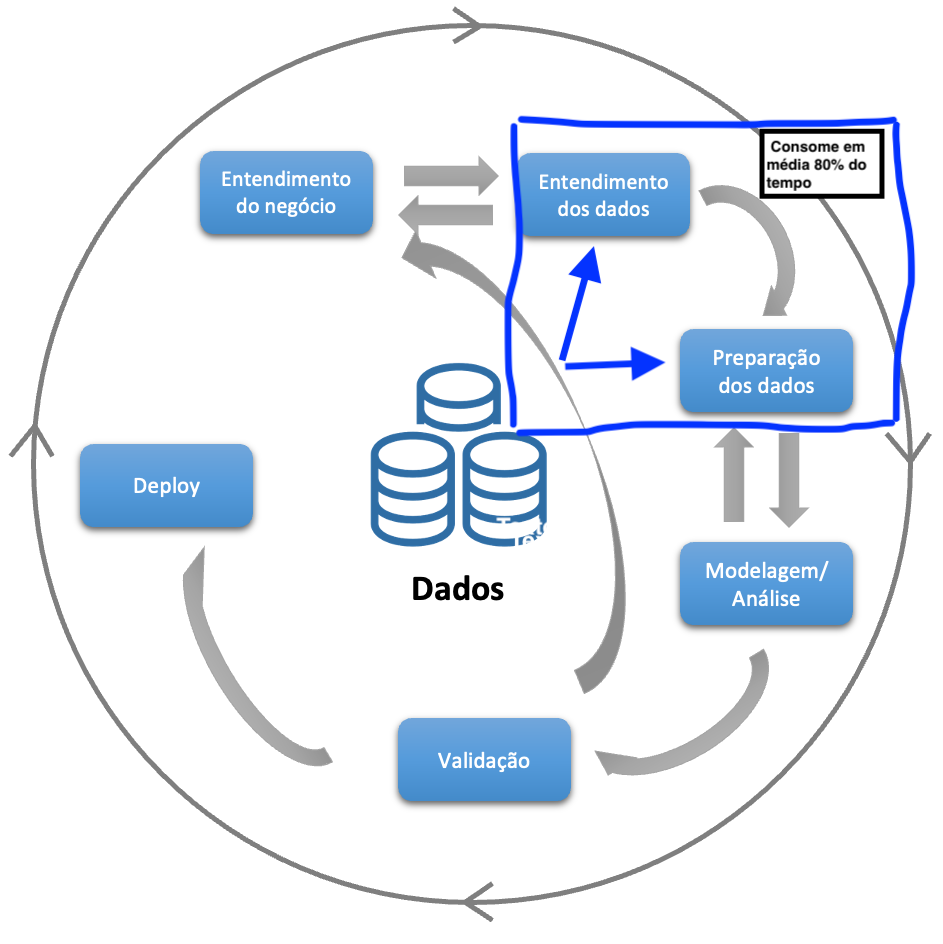

Figura 1: Fase 2 (Compreensão dos Dados) e Fase 3 (Preparação dos dados) consomem entre 60-80% do tempo de um projeto de análise ou ciência de dados

# Metapacote tidyverse

**Descrição**

- O [tidyverse](https://www.tidyverse.org) é um ecossistema coerente de pacotes R para ciência de dados que compartilham uma filosofia de design e gramática comuns.
- Desenvolvido por Hadley Wickham e mantido pela Posit, o tidyverse facilita todo o fluxo de trabalho de análise de dados através de pacotes integrados.

**Alguns dos Principais Pacotes do tidyverse:**

- **readr/readxl**: Importação eficiente de dados retangulares
- **tidyr**: Estruturação de dados no formato “tidy” (pivot_longer, pivot_wider)
- **dplyr**: Manipulação de dados com verbos intuitivos (filter, select, mutate)
- **ggplot2/gt**: Visualização de dados baseada na gramática dos gráficos
- O tidyverse implementa o princípio de “tidy data”, criando um fluxo de trabalho coeso através do operador pipe (%>% ou |>).

## CRISP-DM e tidyverse

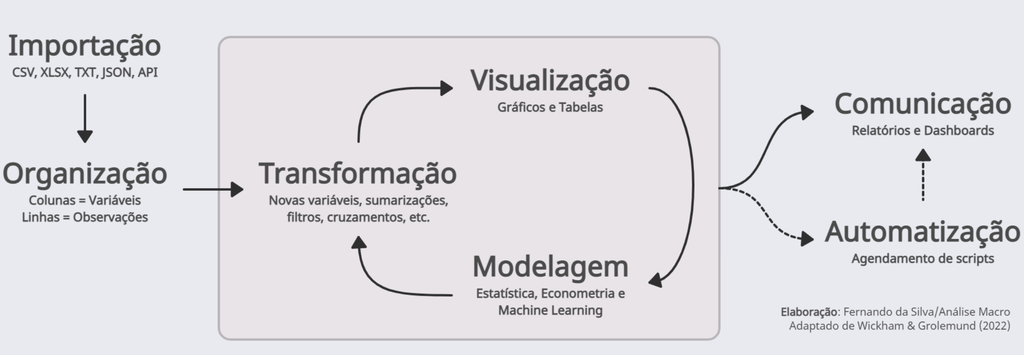

Figura 2: Os pacotes do tidyverse implementam cada fase de CRISP-DM, transformando princípios metodológicos abstratos em ferramentas computacionais que agilizam o processo científico de análise de dados

# Revisão sobre Dados Organizados (*Tidy Data*)

## Dados Organizados

**Conceito de Dados **Organizados** (Tidy Data)**

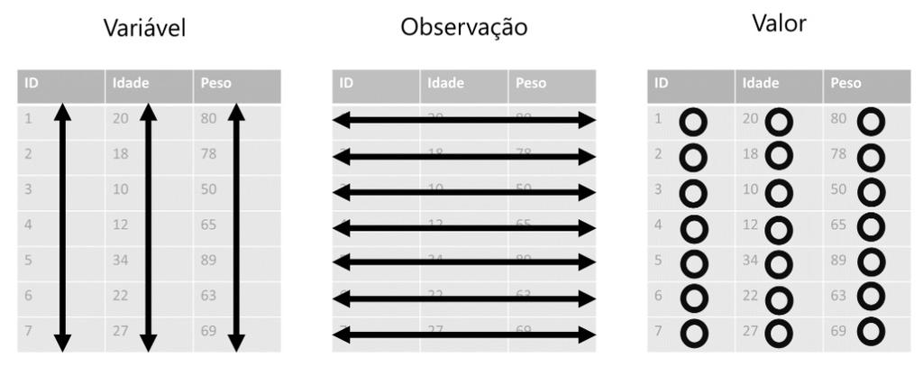

Figura 3: Dados Organizados

## Dados Organizados

**Benefícios de Dados Organizados**

- **Adequação para Ferramentas**: Formato de armazenamento de dados adequado para análise em linguagens (R/Python) e softwares de análise de dados.
- **Consistência**: Estrutura uniforme para todos os conjuntos de dados
- **Facilidade para operações comuns**:
  - Filtragem de observações
  - Seleção de variáveis
  - Criação de novas variáveis
  - Agregação de dados
  - Junção de múltiplas tabelas

## Dados Desorganizados

**Dados Financeiros Desorganizados Típicos**

**Colunas contendo valores**: Nomes de colunas contendo valores de uma ou mais variáveis.

- Ex: Colunas nomeadas com anos (2020, 2021, 2022)

```markdown
| Empresa   | 2020    | 2021    | 2022    |
|-----------|---------|---------|---------|
| Empresa A | 350.000 | 425.000 | 510.000 |
| Empresa B | 780.000 | 815.000 | 840.000 |
| Empresa C | 540.000 | 490.000 | 620.000 |
```

## Dados Organizados

**Versão Organizada dos Dados Anteriores:**

```markdown
| Empresa   | Ano  | Valor   |
|-----------|------|---------|
| Empresa A | 2020 | 350.000 |
| Empresa A | 2021 | 425.000 |
| Empresa A | 2022 | 510.000 |
| Empresa B | 2020 | 780.000 |
| Empresa B | 2021 | 815.000 |
| Empresa B | 2022 | 840.000 |
| Empresa C | 2020 | 540.000 |
| Empresa C | 2021 | 490.000 |
| Empresa C | 2022 | 620.000 |
```

**Características:**

- Cada variável está em uma coluna separada
- Cada observação está em uma linha
- Cada célula contém um valor único

## Dados Desorganizados

**Tipos de “Desorganização” Comuns em Administração**

**Múltiplas variáveis em uma coluna**: Uma coluna contendo mais de uma variável

- Ex: “Nome_Empresa (Ano)” combinando empresa e ano

```markdown
| Nome_Empresa (Ano) | Receita       | Despesa       |
|--------------------|---------------|---------------|
| Empresa A (2020)   | R$ 350.000,00 | R$ 290.000,00 |
| Empresa A (2021)   | R$ 425.000,00 | R$ 320.000,00 |
| Empresa B (2020)   | R$ 780.000,00 | R$ 710.000,00 |
| Empresa B (2021)   | R$ 815.000,00 | R$ 735.000,00 |
```

- **Não** se deve usar unidades (R$ no caso) em arquivos para armazenamento de dados para análise.

## Dados Organizados

**Versão Organizada dos Dados**:

```markdown
| Empresa    | Ano  | Receita  | Despesa  |
|------------|------|----------|----------|
| Empresa A  | 2020 | 350000   | 290000   |
| Empresa A  | 2021 | 425000   | 320000   |
| Empresa B  | 2020 | 780000   | 710000   |
| Empresa B  | 2021 | 815000   | 735000   |
```

## Dados Desorganizados

**Múltiplas variáveis em uma coluna:**

- Os números referem-se ao lucro líquido trimestral das empresas em milhões de reais:

```markdown
| Empresa    | T1 2023 | T2 2023 | T3 2023 | T4 2023 |
|------------|---------|---------|---------|---------|
| TechSoft   | 25.3    | 31.7    | 28.4    | 35.2    |
| VarejoMax  | 12.8    | 15.4    | 19.3    | 22.7    |
| FinGroup   | 41.6    | 38.9    | 45.2    | 51.8    |
```

- **Problemas:**
  - Valores de uma variável (trimestre) estão nas colunas
  - Não segue o princípio “uma coluna, uma variável”
  - Dificulta análises temporais e comparativas

## Dados Organizados

**Versão Organizada dos Dados**:

```markdown
| Empresa   | Trimestre | Ano  | Lucro_Liquido |
|-----------|-----------|------|---------------|
| TechSoft  | T1        | 2023 | 25.3          |
| TechSoft  | T2        | 2023 | 31.7          |
| TechSoft  | T3        | 2023 | 28.4          |
| TechSoft  | T4        | 2023 | 35.2          |
| VarejoMax | T1        | 2023 | 12.8          |
| VarejoMax | T2        | 2023 | 15.4          |
| VarejoMax | T3        | 2023 | 19.3          |
| VarejoMax | T4        | 2023 | 22.7          |
| FinGroup  | T1        | 2023 | 41.6          |
| FinGroup  | T2        | 2023 | 38.9          |
| FinGroup  | T3        | 2023 | 45.2          |
| FinGroup  | T4        | 2023 | 51.8          |
```

## Dados Desorganizados

**Tipos de “Desorganização” Comuns em Administração**

**Variáveis em linhas e colunas**

- Ex: Planilha de desempenho onde ROE aparece como coluna, mas Lucro Líquido e outras variáveis aparecem nas linhas

```markdown
| Empresa            | ROE (%)       | Liquidez Corrente |
|--------------------|---------------|-------------------|
| Empresa XYZ        | 15,2          | 1,8               |
| Lucro Líquido      | R$ 2.500.000  | -                 |
| Patrimônio Líquido | R$ 16.400.000 | -                 |
| Ativo Circulante   | -             | R$ 3.600.000      |
| Passivo Circulante | -             | R$ 2.000.000      |
```

## Dados Organizados

**Versão Organizada dos Dados**:

```markdown
| Empresa    | Indicador           | Valor       |
|------------|---------------------|-------------|
| Empresa XYZ| ROE                 | 0.152       |
| Empresa XYZ| Liquidez Corrente   | 1.8         |
| Empresa XYZ| Lucro Líquido       | 2500000     |
| Empresa XYZ| Patrimônio Líquido  | 16400000    |
| Empresa XYZ| Ativo Circulante    | 3600000     |
| Empresa XYZ| Passivo Circulante  | 2000000     |
```

## Dados/Planilhas Desorganizados

**Por que a absoluta maioria dos arquivos de dados são desorganizados?**

- Por que a maioria das pessoas que trabalham na área de negócios **não está** familiarizada com os **princípios** da organização de dados para análise e utilizam **planilhas eletrônicas** para trabalhar com dados.
- Planilhas de dados são frequentemente organizadas pensando em **apresentar** os dados ou para tornar a **entrada** de dados mais simples, não em um formato adequado para armazenamento e análise.
- Isso significa que, para a maioria das análises reais, cientistas e analistas de dados **dispendem muito tempo e esforço** organizando e preparando dados elaborados por terceiros.
- A **primeira etapa** é sempre descobrir quais são as **observações** e as **variáveis** associadas a cada observação.

## Dados Organizados na Pesquisa em Finanças

**Benefícios para Dissertações e Artigos Científicos**

Dados organizados viabilizam e facilitam a:

- **Reprodutibilidade**: Formato padronizado que outros pesquisadores podem entender e utilizar
- **Visualizações avançadas**: Estrutura ideal para a criação de diversos tipos de tabelas e gráficos.
- **Análise econométrica**: Adequação imediata para estudos e modelos econométricos em (regressão linear, painel, logit, probit etc.)

## Planilhas Eletrônicas

**Broman e Woo (2018): Riscos para Armazenamento de Dados**

- Planilhas eletrônicas têm **alto risco de erros**: Em 13 auditorias de planilhas reais, uma média de **88%** continham erros (Broman e Woo, 2018).
- Problemas comuns incluem:
  - Conversão automática de formatos (ex: nomes de genes interpretados como datas)
  - Armazenamento de datas de forma diferente entre sistemas operacionais
  - Cálculos incorporados que podem corromper dados originais
  - A mistura de análise, visualização e armazenamento no mesmo arquivo aumenta o risco de comprometer os dados brutos e os resultados.
- Mas dada a ubiquidade de planilhas nas organizações, caso precise usar planilhas para armazenar dados, siga as seguintes boas práticas:

## Data Organization in Spreadsheets

**Recomendações práticas para organizar dados em planilhas.**

- Artigo de Broman e Woo (2018)
- Crie planilhas **organizadas** (uma linha = uma observação, uma coluna = uma variável, uma célula = um valor)
- Seja **consistente** e escolha **bons nomes** para as variáveis:
  - use `snake_case` ou `CamelCase`
  - `Lucro Líquido (R$)` 😱
  - `lucro_liquido` ou `LucroLiquido` 😃
  - **NUNCA use** acentos, caracteres especiais e espaços vaziso para nomes ou valores.
- Escreva **datas** conforme a [Norma ISO 8601](https://pt.wikipedia.org/wiki/ISO_8601):
  - `YYYY-MM-DD`, exemplo: `2025-05-07`

## Data Organization in Spreadsheets

**Recomendações práticas para organizar dados em planilhas.**

- **Sem** células vazias: use hífen (`-`) e no caso de usar R, use `NA`
- Crie um **dicionário dos dados**
- **NUNCA faça cálculos** na planilha dos dados originais/brutos
- **NUNCA use** unidades de medida (R$), cor ou realce como um dado.
  - `R$ 50.000,00` 😱
  - `50000` 😃
  - `10 %` 😱
  - `O.1` 😃
- **Faça backups**
- Use **validação** dos dados para evitar erros
- **Salve** os dados em **arquivos de texto simples** (`.csv`):
  - todas as linguagens (R/Python) e softwares de análises de dados reconhecem facilmente esse formato.

## Organizando Dados

**Pacote tidyr**

Na próxima seção, vamos aprender sobre como o pacote tidyr do tidyverse pode ser usado para tornar alguns tipos de dados desorganizados em dados organizados para análise.

# Introdução ao Pacote tidyr

## O que é o pacote tidyr?

[figure not shown]

**O pacote tidyr no ecossistema tidyverse**

- O [tidyr](https://tidyr.tidyverse.org) é um pacote do tidyverse para **organizar dados desorganizados**
- Seu nome vem de “*tidy*” (organizado) + “r” (R)
- Foi criado para facilitar a transformação de dados desorganizados em dados organizados (*tidy data*) para análise
- É muito útil para a preparação de dados na fase 3 do CRISP-DM (Preparação dos Dados)
- Permite que dados em formatos comuns de planilhas e relatórios sejam transformados em formatos adequados para análise e visualização

## Pacote tidyr e CRISP-DM

**Pacote tidyr e a Fase 3 da CRISP-DM (Preparação de Dados)**

- Na prática, muitos dados corporativos estão em formatos desorganizados:
  - Relatórios trimestrais com várias colunas para cada período
  - Planilhas otimizadas para visualização humana, não para análise
  - Dados exportados de sistemas legados ou ERP
- O pacote **tidyr** permite transformar esses dados desorganizados em dados organizados, essenciais para as fases seguintes do CRISP-DM:
  - Fase 3: Preparação dos Dados ← **estamos aqui!**

## Função principal do tidyr

**A Principal função do pacote tidyr para nós**

## Quando usar o tidyr?

**Situações comuns em Administração**

- Quando você tem **planilhas financeiras** com colunas para diferentes períodos (meses, trimestres, anos)
- Quando você recebe **planilhas Excel** organizadas para visualização humana, mas não para análise de dados.
- Quando precisa **combinar dados** de diferentes fontes que estão em formatos incompatíveis.
- Quando precisa **preparar dados** para visualizações específicas com ggplot2 (gráficos de linhas, facetas, etc.)
- Quando realiza **análises temporais** e precisa converter entre formatos de data/hora.

# A Função tidyr::pivot_longer

## Objetivos de Aprendizagem: pivot_longer()

**Ao final desta seção, você será capaz de:**

- **Aplicar** a função pivot_longer() com seus parâmetros essenciais: `cols`, `names_to` e `values_to`
- **Organizar/Transformar** dados complexos extraindo múltiplas informações de colunas
- **Integrar** pivot_longer() em pipelines de análise com dplyr
- **Implementar** soluções para casos reais de análise de dados administrativos

## O que é a função pivot_longer()?

**Transformando dados de formato amplo para longo**

- A função `pivot_longer()` converte dados do formato **amplo** (wide) para o formato **longo** (long)
- É muito útil quando as colunas contêm **valores** em vez de **variáveis**
- Geralmente, é o primeiro passo para transformar planilhas de negócios em dados organizados para análise (*tidy data*)
- A Figura 4 ilustra o uso desta função

## Função pivot_longer()

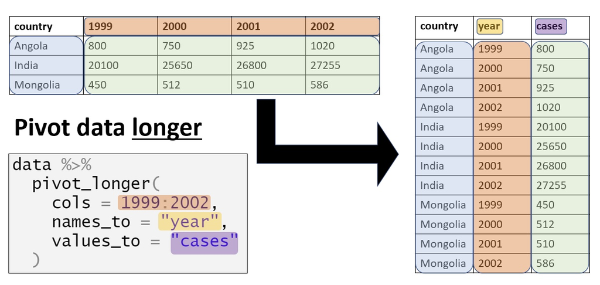

Figura 4: Aplicando a função pivot_longer()

## Sintaxe da função pivot_longer()

**Como usar pivot_longer() na prática**

```r
# Formato básico
dados %>%
  pivot_longer(
    cols = "valores_de_uma_nova_coluna",
    names_to = "nome_nova_coluna",
    values_to = "nome_outra_nova_coluna"
  )
```

- **valores_de_uma_nova_coluna**: as colunas que contêm valores de uma variável e serão transformadas.
- **nome_nova_coluna**: nome da nova coluna/variável que conterá os nomes das colunas originais.
- **nome_outra_nova_coluna**: nome da nova coluna/variável que conterá os valores originais.

## Função pivot_longer

**Descrição**

| Característica | pivot_longer() |
| --- | --- |
| **Transforma** | Colunas → Linhas |
| **Formato resultante** | Longo (mais linhas) |
| **Quando usar** | Para análise e visualização |
| **Exemplo típico** | Transformar colunas de anos em uma variável “ano” |

## A Função tribble()

**Descrição**

A função `tribble()` (abreviação de “*transposed tibble*”) é uma forma elegante de criar pequenas tibbles/data frames para exemplos ou testes:

```r
# Criando uma data frame com tribble() - "tibble transposta"
produtos <- tribble(
  ~codigo, ~produto, ~preco, # Nomes das colunas começam com ~
  "A123", "Notebook", 3500, # Cada linha é um registro
  "B456", "Smartphone", 1800, # Os valores são separados por vírgulas
  "C789", "Monitor", 950 # A formatação facilita a leitura
)

# Visualizando a data frame criada
produtos
```

```
# A tibble: 3 × 3
  codigo produto    preco
  <chr>  <chr>      <dbl>
1 A123   Notebook    3500
2 B456   Smartphone  1800
3 C789   Monitor      950
```

**Vantagens da função tribble():**

- **Layout Visual**: Cada linha do código corresponde a uma linha da data frame, tornando o código mais legível
- **Especificação direta**: Os nomes das colunas são definidos com ~ (til)
- **Flexibilidade de tipos**: Cada coluna pode conter diferentes tipos de dados
- **Ideal para exemplos**: Perfeita para criar pequenas data frames para demonstrações ou testes.

Esta função faz parte do pacote `tibble`, que é carregado automaticamente quando você carrega o `tidyverse`.

## Exemplo Básico de pivot_longer()

**Dados de receita trimestral (formato amplo/wide)**

```r
# Criando a data frame de exemplo
receitas <- tribble(
  ~produto, ~T1, ~T2, ~T3, ~T4,
  "Produto A", 50000, 55000, 60000, 65000,
  "Produto B", 30000, 32000, 35000, 37000,
  "Produto C", 20000, 22000, 25000, 27000
)

# Visualizando a data frame original (formato amplo/wide)
receitas
```

```
# A tibble: 3 × 5
  produto      T1    T2    T3    T4
  <chr>     <dbl> <dbl> <dbl> <dbl>
1 Produto A 50000 55000 60000 65000
2 Produto B 30000 32000 35000 37000
3 Produto C 20000 22000 25000 27000
```

Este formato é para apresentação, não para armazenamento e análise.

## Exemplo Básico de pivot_longer()

**Transformando para o formato longo**

```r
# Transformando para o formato longo usando pivot_longer
receitas_longas <- receitas %>%
  pivot_longer(
    cols = c("T1", "T2", "T3", "T4"), # colunas que serão valores da nova coluna
    names_to = "trimestre", # nome da nova coluna
    values_to = "receita" # nome de outra nova coluna
  )

# Visualizando o resultado (formato longo/long)
receitas_longas
```

```
# A tibble: 12 × 3
   produto   trimestre receita
   <chr>     <chr>       <dbl>
 1 Produto A T1          50000
 2 Produto A T2          55000
 3 Produto A T3          60000
 4 Produto A T4          65000
 5 Produto B T1          30000
 6 Produto B T2          32000
 7 Produto B T3          35000
 8 Produto B T4          37000
 9 Produto C T1          20000
10 Produto C T2          22000
11 Produto C T3          25000
12 Produto C T4          27000
```

Agora os dados estão organizados:

- Cada linha é uma observação (um produto em um trimestre)
- Cada coluna é uma variável (produto, trimestre, receita)
- Cada célula contém um único valor

## Exemplo Intermediário: Várias Colunas

**Dados de desempenho financeiro**

```r
# Criando a data frame com múltiplas métricas por trimestre
desempenho <- tribble(
  ~empresa, ~receita_T1, ~receita_T2, ~despesa_T1, ~despesa_T2,
  "Empresa A", 150000, 175000, 120000, 130000,
  "Empresa B", 250000, 270000, 200000, 220000,
  "Empresa C", 100000, 115000, 80000, 95000
)

# Visualizando a data frame original
desempenho
```

```
# A tibble: 3 × 5
  empresa   receita_T1 receita_T2 despesa_T1 despesa_T2
  <chr>          <dbl>      <dbl>      <dbl>      <dbl>
1 Empresa A     150000     175000     120000     130000
2 Empresa B     250000     270000     200000     220000
3 Empresa C     100000     115000      80000      95000
```

Este formato é ainda mais desorganizado, pois mistura três variáveis (receita, despesa e trimestre) nos nomes das colunas.

## Exemplo Intermediário: Várias Colunas

**Transformando para o formato longo com dois níveis**

```r
# Transformando para o formato longo usando pivot_longer com nomes separados
desempenho_longo <- desempenho %>%
  pivot_longer(
    cols = -empresa, # todas as colunas exceto "empresa"
    names_to = c("indicador", "trimestre"), # nomes das duas novas colunas
    names_sep = "_", # separador nos nomes das colunas
    values_to = "valor" # nome de nova coluna para receber os valores
  )

# Visualizando o resultado
desempenho_longo
```

```
# A tibble: 12 × 4
   empresa   indicador trimestre  valor
   <chr>     <chr>     <chr>      <dbl>
 1 Empresa A receita   T1        150000
 2 Empresa A receita   T2        175000
 3 Empresa A despesa   T1        120000
 4 Empresa A despesa   T2        130000
 5 Empresa B receita   T1        250000
 6 Empresa B receita   T2        270000
 7 Empresa B despesa   T1        200000
 8 Empresa B despesa   T2        220000
 9 Empresa C receita   T1        100000
10 Empresa C receita   T2        115000
11 Empresa C despesa   T1         80000
12 Empresa C despesa   T2         95000
```

**Observação importante:**

- Os nomes das colunas originais (`receita_T1`, `receita_T2`, etc.) são divididos pelo separador “_” em exatamente duas partes.
- A primeira parte (“receita” ou “despesa”) vai para a coluna “indicador” e a segunda parte (“T1” ou “T2”) vai para a coluna “trimestre”.
- Este é um padrão comum em dados financeiros: quando os nomes de colunas seguem um formato consistente com separadores, podemos extrair as informações contidas neles para criar novas variáveis.

## Exemplo Avançado

**Indicadores financeiros por trimestre**

```r
# Exemplo mais gerenciável para slides
receita_trimestral <- tribble(
  ~empresa, ~`2022_T1_Receita`, ~`2022_T2_Receita`, ~`2023_T1_Receita`, ~`2023_T2_Receita`,
  "ABC Ltda", 1200000, 1350000, 1500000, 1620000,
  "XYZ S.A.", 2500000, 2700000, 2900000, 3100000
)

# Visualizando a data frame original
receita_trimestral
```

```
# A tibble: 2 × 5
  empresa  `2022_T1_Receita` `2022_T2_Receita` `2023_T1_Receita`
  <chr>                <dbl>             <dbl>             <dbl>
1 ABC Ltda           1200000           1350000           1500000
2 XYZ S.A.           2500000           2700000           2900000
# ℹ 1 more variable: `2023_T2_Receita` <dbl>
```

- Temos informações de ano e trimestre nos nomes das colunas

## Exemplo Avançado

**Organizando dados financeiros complexos**

```r
# Transformando para o formato longo usando pivot_longer com três níveis
receita_trimestral_organizada <- receita_trimestral %>%
  pivot_longer(
    cols = -empresa, # todas as colunas exceto "empresa"
    names_to = c("ano", "trimestre"), # nomes de duas novas colunas
    names_sep = "_", # separador nos nomes das colunas
    values_to = "receita" # nome de nova coluna para receber os valores da receita
  )

# Visualizando o resultado
receita_trimestral_organizada
```

```
# A tibble: 8 × 4
  empresa  ano   trimestre receita
  <chr>    <chr> <chr>       <dbl>
1 ABC Ltda 2022  T1        1200000
2 ABC Ltda 2022  T2        1350000
3 ABC Ltda 2023  T1        1500000
4 ABC Ltda 2023  T2        1620000
5 XYZ S.A. 2022  T1        2500000
6 XYZ S.A. 2022  T2        2700000
7 XYZ S.A. 2023  T1        2900000
8 XYZ S.A. 2023  T2        3100000
```

## Resumo: Função pivot_longer()

**O que você precisa lembrar**

1. **Finalidade**: Transformar dados do formato amplo (wide) para o formato longo (long), organizando-os conforme o princípio tidy data
2. **Sintaxe básica**:

```r
dados %>%
  pivot_longer(
    cols = colunas_a_transformar,
    names_to = "nome_nova_coluna_para_nomes",
    values_to = "nome_nova_coluna_para_valores"
  )
```

3. **Parâmetros principais**:
- `cols`: Quais colunas serão transformadas em pares nome-valor
- `names_to`: Nome da nova coluna que receberá os nomes das colunas originais
- `values_to`: Nome da nova coluna que receberá os valores

4. **Caso avançado**:

- Quando os nomes de colunas contêm múltiplas informações, use:
  - `names_to = c("variavel1", "variavel2", ...)`
  - `names_sep = "_"` (ou outro separador presente nos nomes)

5. **Benefícios**:

- Padroniza o formato de dados conforme princípios da ciência de dados
- Facilita análises com dplyr (group_by, summarize, etc.)
- Prepara dados para visualizações eficientes

## Sua Vez: Aplicando o Conhecimento

**Organizando dados na prática**

- A seguir, aplicaremos os conceitos aprendidos em exercícios práticos que simulam situações reais na área de Administração.
- Tente resolver os exercícios usando o que aprendemos sobre:
  - Identificação de dados desorganizados
  - Aplicação da função pivot_longer()
  - Criação de estruturas organizadas para análise
- Ao resolver estes exercícios, imagine como você poderia aplicar estas técnicas em:
  - Análises de desempenho de vendas
  - Avaliação de eficácia de estratégias de marketing
  - Planejamento financeiro e orçamentário
- **Lembre-se**: No mundo real do trabalho, a capacidade de reorganizar dados rapidamente para extrair insights é uma habilidade crítica para administradores

## Exercícios com pivot_longer()

**Nível Básico**

1. Você trabalha no departamento de vendas de uma rede de lojas e recebeu os dados trimestrais das vendas de cada loja em 2024. Os dados estão no formato “amplo” conforme abaixo:

```r
vendas_lojas <- tribble(
  ~loja, ~T1, ~T2, ~T3, ~T4,
  "Shopping Central", 185000, 162000, 198000, 230000,
  "Centro Comercial", 145000, 152000, 138000, 176000,
  "Mall Express", 92000, 98000, 103000, 125000,
  "Galeria Norte", 78000, 83000, 89000, 110000
)

# Visualizando os dados originais
vendas_lojas
```

```
# A tibble: 4 × 5
  loja                 T1     T2     T3     T4
  <chr>             <dbl>  <dbl>  <dbl>  <dbl>
1 Shopping Central 185000 162000 198000 230000
2 Centro Comercial 145000 152000 138000 176000
3 Mall Express      92000  98000 103000 125000
4 Galeria Norte     78000  83000  89000 110000
```

Transforme estes dados para o formato “longo” (tidy), criando as variáveis “trimestre” e “vendas”.

## Exercícios com pivot_longer()

**Nível Intermediário 1**

2. Você é analista financeiro e recebeu dados sobre os investimentos da empresa em marketing digital por plataforma nos últimos 3 meses. Os dados estão no seguinte formato:

```r
investimentos_marketing <- tribble(
  ~plataforma, ~Jan, ~Fev, ~Mar,
  "Google Ads", 12500, 13200, 15000,
  "Facebook", 8700, 9300, 10500,
  "Instagram", 7200, 8500, 9800,
  "LinkedIn", 5400, 5800, 6500
)

# Visualizando os dados originais
investimentos_marketing
```

```
# A tibble: 4 × 4
  plataforma   Jan   Fev   Mar
  <chr>      <dbl> <dbl> <dbl>
1 Google Ads 12500 13200 15000
2 Facebook    8700  9300 10500
3 Instagram   7200  8500  9800
4 LinkedIn    5400  5800  6500
```

Seu gestor pediu para você transformar estes dados em um formato que permita:

- Realizar análises por plataforma
- Comparar investimentos mês a mês
- Identificar a plataforma com maior crescimento

Transforme estes dados para o formato adequado para estas análises.

## Exercícios com pivot_longer()

**Nível Intermediário 2**

3. A diretoria solicitou uma análise detalhada de despesas e receitas mensais por departamento no primeiro semestre de 2024. Os dados foram enviados no seguinte formato:

```r
incidadores_dptos <- tribble(
  ~departamento, ~Jan_receita, ~Jan_despesa, ~Fev_receita, ~Fev_despesa, ~Mar_receita, ~Mar_despesa, ~Abr_receita, ~Abr_despesa, ~Mai_receita, ~Mai_despesa, ~Jun_receita, ~Jun_despesa,
  "Vendas", 120000, 85000, 125000, 82000, 135000, 90000, 122000, 88000, 140000, 91000, 145000, 94000,
  "Marketing", 45000, 38000, 52000, 46000, 48000, 42000, 55000, 49000, 58000, 52000, 62000, 54000,
  "Produção", 180000, 152000, 185000, 158000, 192000, 160000, 195000, 162000, 210000, 170000, 215000, 175000,
  "RH", 28000, 25000, 28000, 25000, 30000, 26000, 29000, 26000, 31000, 27000, 32000, 28000
)

# Visualizando os dados originais
incidadores_dptos
```

```
# A tibble: 4 × 13
  departamento Jan_receita Jan_despesa Fev_receita Fev_despesa Mar_receita
  <chr>              <dbl>       <dbl>       <dbl>       <dbl>       <dbl>
1 Vendas            120000       85000      125000       82000      135000
2 Marketing          45000       38000       52000       46000       48000
3 Produção          180000      152000      185000      158000      192000
4 RH                 28000       25000       28000       25000       30000
# ℹ 7 more variables: Mar_despesa <dbl>, Abr_receita <dbl>, Abr_despesa <dbl>,
#   Mai_receita <dbl>, Mai_despesa <dbl>, Jun_receita <dbl>, Jun_despesa <dbl>
```

Reorganize estes dados para o formato longo, separando corretamente as informações de mês, indicador (receita/despesa) e valor.

## Dicas para Trabalhar com tidyr

**Recomendações práticas**

1. **Identifique as variáveis**: Antes de transformar, identifique claramente quais são as observações e variáveis reais nos seus dados
2. **Comece com subconjuntos**: Para dados complexos, comece testando com um pequeno subconjunto de dados
3. **Use nomes descritivos**: Escolha bons nomes para as novas colunas criadas por `pivot_longer()`
4. **Combine com dplyr**: As transformações com tidyr geralmente são seguidas por operações com dplyr para análise
5. **Verifique os resultados**: Sempre confira se os dados transformados mantêm as mesmas informações dos dados originais

## Resumo: Pacote tidyr

**O que você precisa lembrar**

1. **O que faz**: O pacote tidyr transforma dados entre os formatos amplo (wide) e longo (long)
2. **Principal função**:
   - `pivot_longer()`: Converte de amplo (*wide*) para longo (*long*) (colunas para linhas)
3. **Quando usar**:
   - Use `pivot_longer()` quando colunas contiverem valores em vez de variáveis
4. **Importância na análise de dados**:
   - É essencial para a preparação de dados (fase 3 do CRISP-DM)
   - Permite transformar dados comuns de negócios em formatos adequados para análise
   - Facilita a aplicação de funções do dplyr e criação de visualizações
5. **Lembre-se sempre**:
   - Dados organizados (tidy) têm uma variável por coluna, uma observação por linha.

## Pacote tidyr: Bibliografia Recomendada

- [R para Ciência de Dados - Cap. 5](http://pt.r4ds.hadley.nz/data-tidy.html)
- [Introdução à Linguagem R - Cap. 7](https://pedropark99.github.io/Introducao_R/Cap%C3%ADtulos/07-tidy-data.html)
- [Resumo do tidyr](https://rstudio.github.io/cheatsheets/tidyr.pdf)

# Introdução ao Pacote dplyr

## O que é o dplyr?

**O pacote dplyr no ecossistema tidyverse**

- O [dplyr](https://dplyr.tidyverse.org/index.html) é um dos pacotes principais do [tidyverse](https://www.tidyverse.org), criado por Hadley Wickham
- Seu nome vem de “*data plier*” (alicate para dados) - uma ferramenta para manipular dados
- Foi projetado seguindo a filosofia “*tidy data*” (dados organizados) - cada variável é uma coluna, cada observação é uma linha
- É escrito em C++ para performance otimizada
- Permite manipulação de dados de forma consistente, clara e encadeada

## O dplyr no Ecossistema R

**Contexto do dplyr**

- O pacote dplyr é parte do **tidyverse**
- Enquanto os pacotes **readr** e **readxl** ajudam na importação de dados, o dplyr é especializado na **manipulação** de dados
- O dplyr foi otimizado para manipular sobre **dados organizados**, longos ou *tidy data*
- O dplyr trabalha com uma estrutura de dados de R que já conhecemos: **data frames/tibbles**
- As funções do dplyr foram projetadas para serem usadas com o operador pipe (`%>%`), que já vimos brevemente no relatório Junglivet

## Uma Analogia para o dplyr

**O dplyr como uma “linha de produção”**

Imagine o processo de análise de dados como uma linha de produção:

- Os **dados brutos** são sua “matéria-prima”
- Cada função do dplyr é uma “estação de trabalho” que realiza uma operação específica:
  - `filter()` seleciona apenas os materiais que atendem a certos critérios
  - `select()` separa apenas as partes que você precisa
  - `mutate()` transforma ou cria novos componentes
  - `group_by()` + `summarize()` agrupam e calculam estatísticas
  - `arrange()` organiza o resultado final
- O operador pipe (`%>%`) é a “esteira” que move os dados de uma estação para outra

## Operações Comuns em Análise de Dados

**Operações rotineiras**

- Muitas vezes precisamos **filtrar** somente certas linhas (**observações** ) de uma data frame.
- Muitas vezes precisamos **selecionar** somente certas colunas (**variáveis**) de uma data frame.
- Muitas vezes precisamos **agrupar** os dados por uma determinada(s) variável(s) categórica.
- Muitas vezes precisamos **calcular estatísticas descritivas** para esses subconjuntos de dados (função `summarize`).

## Por que usar o dplyr?

- Usando R base:

```r
# pib per capita médio dos países do continente americano
mean(gapminder$gdpPercap[gapminder$continent == "Americas"])
```

```
[1] 7136.11
```

- Usando o pacote dplyr

```r
# pib per capita médio dos países do continente americano
gapminder %>%
  filter(continent == "Americas") %>%
  summarize(mean(gdpPercap))
```

```
# A tibble: 1 × 1
  `mean(gdpPercap)`
              <dbl>
1             7136.
```

## Por que usar o dplyr?

**R base (aninhado):**

```r
# Calcular a média de PIB per capita para
# países asiáticos com população > 50 milhões
# em 2007
mean(gapminder$gdpPercap[
  gapminder$continent == "Asia" &
  gapminder$pop > 50000000 &
  gapminder$year == 2007
])
```

- Difícil de ler e entender
- Propenso a erros
- Difícil de modificar

**Com dplyr e pipe:**

```r
# O mesmo cálculo com dplyr
gapminder %>%
  filter(
    continent == "Asia",
    pop > 50000000,
    year == 2007
  ) %>%
  summarize(mean(gdpPercap))
```

- Leitura sequencial, mais natural
- Cada etapa claramente separada
- Fácil de modificar ou expandir

## Comparando Abordagens

**Vantagens e Desvantagens**

**Base R: Funções aninhadas**

- **Vantagens**: Não requer pacotes adicionais, disponível em qualquer instalação do R
- **Desvantagens**:
  - Código difícil de ler com funções aninhadas
  - Difícil de depurar quando há erros
  - Funções com sintaxes inconsistentes

**dplyr: Gramática da manipulação de dados**

- **Vantagens**:
  - Código mais legível e expressivo
  - Funções com nomes intuitivos e consistentes
  - Ideal para análises sequenciais com pipes
- **Desvantagens**:
  - Requer aprender uma nova sintaxe (para usuários experientes)
  - Dependência de pacotes externos
  - Algumas operações podem ser mais lentas que o R base em casos específicos

## Fluxo de trabalho com tidyvese

**Gramática da manipulação de dados**

O fluxo típico de uma análise de dados com tidyverse segue este padrão:

1. **Importar** dados (com pacotes here, readr, readxl,…)
2. **Organizar** dados para análise (pacote tidyr)
3. **Unir** arquivos/tabelas se necessário (funções para `joins`)
4. **Filtrar** observações (função `filter`)
5. **Selecionar** variáveis (função `select`)
6. **Transformar** dados (função `mutate`)
7. **Agrupar** dados (função `group_by`)
8. **Resumir** informações (função `summarize`)
9. **Ordenar** resultados (função `arrange`)

## Um Pipeline de Análise com dplyr

**Informações sobre expectativa de vida por continente**

```r
# Um pipeline de análise com dplyr
relatorio_expectativa <- gapminder %>%
  # Filtra apenas os dados de 2007
  filter(year == 2007) %>%
  # Agrupa por continente
  group_by(continent) %>%
  # Calcula estatísticas resumidas
  summarize(
    expectativa_media = mean(lifeExp),
    expectativa_minima = min(lifeExp),
    expectativa_maxima = max(lifeExp),
    num_paises = n()
  ) %>%
  # Ordena do maior para o menor
  arrange(desc(expectativa_media))

# Visualiza o resultado final
relatorio_expectativa
```

Este exemplo demonstra como um conjunto de funções do dplyr pode ser combinado para transformar dados brutos **organizados** em um relatório informativo com apenas algumas linhas de código.

## Conexão com o Relatório Junglivet

**O que já vimos na prática**

No relatório Junglivet, já utilizamos algumas funções do dplyr:

```r
# Trecho do relatório Junglivet
dados_destilaria_limpos <- dados_destilaria %>%
  # Remove a coluna MONTH
  select(-MONTH) %>%
  # Renomeia as colunas
  rename(
    dia = DAY,
    mestre_responsavel = MANUFACTURER,
    # ... outras colunas renomeadas
  ) %>%
  # Converte cada variável para seu tipo adequado
  mutate(
    dia = as.numeric(dia),
    # ... outras conversões
  ) %>%
  # Remove linhas com valores ausentes
  drop_na()
```

Agora vamos entender em detalhes cada uma dessas funções e como aplicá-las em diferentes contextos de análise de dados.

## Pacote dplyr

**Pacote dplyr: Vantagens**

O pacote dplyr fornece uma série de funções muito úteis para manipular data frames de uma maneira que:

- reduz a probabilidade de cometer erros
- economiza digitação
- o código é mais legível e compreensível

## Pacote dplyr

**Objetivos de Aprendizagem**

| Função | Descrição |
| --- | --- |
| `dplyr::filter()` | para filtrar linhas (observações) |
| `dplyr::select()` | para selecionar colunas (variáveis ) |
| `dplyr::mutate()` | para criar novas variáveis |
| `dplyr::group_by()` | para operações “por grupo” |
| `dplyr::summarize()` | para calcular estatísticas |
| `dplyr::arrange()` | para ordenar resultados |

Além disso, veremos como como usar o operador pipe (`%>%`) para combiná-las.

## Boas Práticas com dplyr

**Recomendações para código eficiente e legível**

1. **Indentação consistente**:
   - Um nível de identação para cada função
   - Parâmetros adicionais alinhados
2. **Nomeie seu código**:
   - Use nomes descritivos para variáveis intermediárias e finais
   - Ex: `dados_filtrados`, `relatorio_vendas_por_regiao`
3. **Comente seu código**:
   - Explique o “por quê”, não apenas o “o quê”
   - Útil para você mesmo no futuro e para colegas
4. **Dividir análises complexas em etapas**:
   - Para análises muito complexas, divida em objetos intermediários
   - Facilita a depuração e compreensão
5. **Consistência de estilo**:
   - Seja consistente com o estilo de nomeação (snake_case ou CamelCase)
   - Seja consistente com o uso de aspas (simples ou duplas)

# Dados dos Exemplos com dplyr

## Pacote gapminder

**Descrição**

- O pacote gapminder da linguagem R contém uma data frame também chamada gapminder.
- A df gapminder fornece informações detalhadas sobre indicadores socioeconômicos reais de vários países ao longo do tempo.
- Este conjunto de dados é muito utilizado no ensino da linguagem R e de métodos estatísticos.
- Vamos utilizar a df gapminder para ilustrar as funções do pacote dplyr.

A sigla df = data frame

## Pacote gapminder

**Após instalar, carregue o pacote**

- Para acessar os dados gapminder, basta instalar e carregar o pacote gapminder:

```r
# carrega os pacotes
library(tidyverse)
library(gapminder)
```

## Data Frame gapminder

Para obter uma visão geral da estrutura da df gapminder, podemos usar a função glimpse do pacote dplyr:

```r
# visualizando a estrutura dos dados
dplyr::glimpse(gapminder)
```

```
Rows: 1,704
Columns: 6
$ country   <fct> "Afghanistan", "Afghanistan", "Afghanistan", "Afghanistan", …
$ continent <fct> Asia, Asia, Asia, Asia, Asia, Asia, Asia, Asia, Asia, Asia, …
$ year      <int> 1952, 1957, 1962, 1967, 1972, 1977, 1982, 1987, 1992, 1997, …
$ lifeExp   <dbl> 28.801, 30.332, 31.997, 34.020, 36.088, 38.438, 39.854, 40.8…
$ pop       <int> 8425333, 9240934, 10267083, 11537966, 13079460, 14880372, 12…
$ gdpPercap <dbl> 779.4453, 820.8530, 853.1007, 836.1971, 739.9811, 786.1134, …
```

Podemos também inspecionar as primeiras 6 linhas da data frame com a função head:

```r
head(gapminder)
```

```
# A tibble: 6 × 6
  country     continent  year lifeExp      pop gdpPercap
  <fct>       <fct>     <int>   <dbl>    <int>     <dbl>
1 Afghanistan Asia       1952    28.8  8425333      779.
2 Afghanistan Asia       1957    30.3  9240934      821.
3 Afghanistan Asia       1962    32.0 10267083      853.
4 Afghanistan Asia       1967    34.0 11537966      836.
5 Afghanistan Asia       1972    36.1 13079460      740.
6 Afghanistan Asia       1977    38.4 14880372      786.
```

## Boa Prática

**Dicionário dos dados**

A data frame gapminder contida no pacote de mesmo nome, possui 1704 linhas (observações) e 6 colunas (variáveis).

| Variável | Classe/Tipo | Descrição |
| --- | --- | --- |
| `country` | `factor` | Nome do país (142 níveis/países) |
| `continent` | `factor` | Continente ao qual o país pertence (5 níveis/continentes) |
| `year` | `integer` | Ano da observação (1952 a 2007 em incrementos de 5 anos) |
| `lifeExp` | `double` | Expectativa de vida ao nascer, em anos |
| `pop` | `integer` | População total do país |
| `gdpPercap` | `double` | PIB per capita em US$, ajustado pela inflação |

# Função dplyr::select()

## O que é a função select()?

**Selecionando variáveis (colunas) de uma data frame**

- A função `select()` permite escolher quais **variáveis** (colunas) você quer manter ou remover de uma data frame
- Enquanto `select()` trabalha com **colunas** (variáveis), `filter()` trabalha com **linhas** (observações),
- É essencial para simplificar seus dados, focando apenas nas variáveis relevantes para sua análise

## Função select()

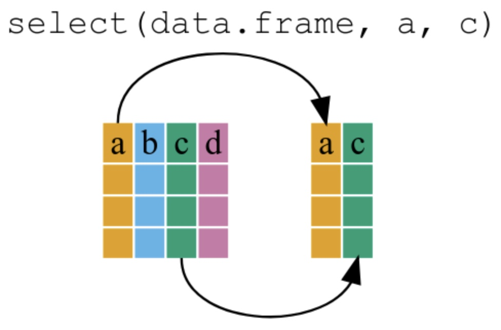

## Sintaxe da função select()

**Sintaxe básica**

```r
# Estrutura básica
select(df, var1, var2, var3)

# Com operador pipe
df %>% select(var1, var2, var3)
```

- **df**: A data frame da qual você quer selecionar variáveis
- **var1, var2, var3**: Nomes das variáveis que você quer manter
- Todas as variáveis não listadas serão removidas do resultado

## Exemplo: Análise Financeira Simplificada

**Cenário: Análise financeira de países**

Imagine que você é um analista financeiro internacional e precisa preparar um relatório sobre PIB:

```r
# Seleciona apenas as variáveis relevantes para análise financeira
dados_financeiros <- gapminder %>%
  select(country, year, gdpPercap)

# Visualiza as primeiras linhas do resultado
head(dados_financeiros)
```

```
# A tibble: 6 × 3
  country      year gdpPercap
  <fct>       <int>     <dbl>
1 Afghanistan  1952      779.
2 Afghanistan  1957      821.
3 Afghanistan  1962      853.
4 Afghanistan  1967      836.
5 Afghanistan  1972      740.
6 Afghanistan  1977      786.
```

**Interpretação:** Este código seria equivalente a extrair apenas os dados financeiros relevantes (país, ano e PIB per capita) de uma grande base de dados para uma análise específica de desempenho econômico.

## Técnicas de Seleção Avançadas

**Diversas formas de selecionar variáveis**

```r
# Selecionar variáveis por inclusão
gapminder %>% select(country, year, gdpPercap)

# Selecionar variáveis por exclusão (com sinal de menos)
gapminder %>% select(-continent, -lifeExp)

# Selecionar variáveis em sequência
gapminder %>% select(country:pop)

# Selecionar variáveis que começam com determinado texto
gapminder %>% select(starts_with("c"))

# Selecionar variáveis que terminam com determinado texto
gapminder %>% select(ends_with("p"))

# Selecionar variáveis que contêm determinado texto
gapminder %>% select(contains("exp"))
```

## Técnicas de Seleção Avançadas

**Aplicações práticas em negócios**

Estas técnicas são muito úteis quando você trabalha com:

- Grandes conjuntos de dados com dezenas ou centenas de variáveis
- Planilhas de dados financeiros onde precisa focar em determinadas métricas
- Relatórios onde precisa apresentar apenas informações específicas

## Erros Comuns e Como Evitá-los

**Os erros mais comuns com select()**

| Erro | Errado | Correto |
| --- | --- | --- |
| Nomes de variáveis com aspas | `select(gapminder, "country")` | `select(gapminder, country)` |
| Tentar condições como em filter | `select(gapminder, gdpPercap > 1000)` | Use `filter()` para isso, não `select()` |
| Não salvar o resultado | `gapminder %>% select(country, year)` | `dados_novos <- gapminder %>% select(country, year)` |
| Remover variáveis necessárias | `select(country)` e depois tentar usar `continent` | Verifique se manteve todas as variáveis necessárias |

**Dica importante:**

Lembre-se: `select()` é para escolher **colunas (variáveis)** e `filter()` é para escolher **linhas (observações)**!

## Exemplo: Salvando o resultado

**Seleção por Exclusão**

- Se quisermos remover apenas a variável **continent**, podemos usar a sintáxe abaixo e salvar o resultado em outro objeto:

```r
variaveis_selecionadas <- select(gapminder, -continent)
variaveis_selecionadas
```

```
# A tibble: 1,704 × 5
   country      year lifeExp      pop gdpPercap
   <fct>       <int>   <dbl>    <int>     <dbl>
 1 Afghanistan  1952    28.8  8425333      779.
 2 Afghanistan  1957    30.3  9240934      821.
 3 Afghanistan  1962    32.0 10267083      853.
 4 Afghanistan  1967    34.0 11537966      836.
 5 Afghanistan  1972    36.1 13079460      740.
 6 Afghanistan  1977    38.4 14880372      786.
 7 Afghanistan  1982    39.9 12881816      978.
 8 Afghanistan  1987    40.8 13867957      852.
 9 Afghanistan  1992    41.7 16317921      649.
10 Afghanistan  1997    41.8 22227415      635.
# ℹ 1,694 more rows
```

## Pacote dplyr e o operador `%>%`

**Combinação de Operações com `%>%`**

- Nos slides anteriores, usamos a sintáxe ‘normal’ da linguagem R.
- Mas o ponto forte do dplyr está na **combinação** de várias funções usando o **operador pipe** `%>%`.
- Vamos analisar a gramática do uso de funções do dplyr combinadas com o operador `%>%`.
- Atalho para inserir o operador pipe: **Ctrl + shift + M**

## Operador Pipe: A “cola” da gramática dplyr

**Significado conceitual do pipe %>%**

- O operador pipe pode ser lido como “então” ou “em seguida”
- Fluxo da esquerda para a direita, similar à leitura natural
- Transforma:

`funcao(dados, arg1, arg2)`

em

`dados %>% funcao(arg1, arg2)`

## Operador Pipe

**Analogia**

Uma linha de montagem onde cada função faz uma operação nos dados

```r
gapminder %>% # Pegue os dados gapminder, então...
  filter(year == 2007) %>% # Filtre para apenas o ano 2007, então...
  group_by(continent) %>% # Agrupe por continente, então...
  summarize( # Calcule resumos:
    mean(lifeExp), # expectativa de vida média
    sum(pop) # população total
  )
```

## Dica

**Nomeie os resumos calculados com summarize**

```r
gapminder %>% # Pegue os dados gapminder, então...
  filter(year == 2007) %>% # Filtre para apenas o ano 2007, então...
  group_by(continent) %>% # Agrupe por continente, então...
  summarize( # Calcule resumos:
    exp_vida_media = mean(lifeExp), # expectativa de vida média
    populacao_total = sum(pop) # população total
  )
```

## Função select() e o Operador Pipe

**Dica**

```r
variaveis_selecionadas <- gapminder %>%
  dplyr::select(year, country, gdpPercap)
```

Vamos entender o código:

1. Primeiro invocamos a df gapminder e a passamos, usando o operador pipe `%>%`, para a próxima etapa, que é a função select().
2. Neste caso, não especificamos qual df usamos na função select(), porque que ela obtém essa informação do pipe anterior.
3. Salvamos o resultado no objeto `variaveis_selecionadas`

## Resumo: Função select()

**O que você precisa lembrar**

1. **Para que serve:** Selecionar apenas as colunas (variáveis) que você deseja manter ou remover
2. **Sintaxe básica:**

```r
dados %>% select(var1, var2, var3)  # Mantém apenas var1, var2 e var3
dados %>% select(-var4, -var5)      # Remove var4 e var5, mantém o resto
```

3. **Técnicas úteis:**
   - Seleção por inclusão: `select(país, ano, vendas)`
   - Seleção po exclusão: `select(-observações, -notas)`
   - Seleção por padrão de texto: `select(starts_with("venda"))`
4. **Lembre-se sempre:**
   - `select()` trabalha com COLUNAS
   - `filter()` trabalha com LINHAS
   - Sempre salve o resultado em um novo objeto!

```r
novo_df <- dados %>% select(...)
```

## Sua vez

**Exercícios Práticos com select()**

**Nível 1: Primeiros Passos**

1. Complete o código abaixo para selecionar apenas o país, o ano e a expectativa de vida:

```r
dados_expectativa <- gapminder %>%
  select(___, ___, ___)
```

2. Escreva o código para selecionar todas as variáveis EXCETO população e PIB per capita.

**Nível 2: Técnicas Avançadas com select()**

3. Complete o código abaixo para selecionar apenas as variáveis que começam com a letra “c”:

```r
variaveis_com_c <- gapminder %>%
  select(___(___))
```

4. Escreva o código para selecionar todas as variáveis desde “country” até “pop” (em sequência na tabela).

**Desafio:** Crie um código que selecione variáveis usando dois métodos diferentes na mesma instrução:

- Todas as variáveis que contêm a letra “p” OU
- Todas as variáveis que terminam com “p”

**Dica:** Lembre-se que você pode combinar seleções com vírgulas e use o atalho Ctrl+Shift+M para inserir o operador pipe (%>%).

# Função dplyr::filter()

## O que é a função filter()?

**Filtrando observações (linhas) de uma data frame**

- A função `filter()` permite **filtrar subconjuntos de observações** (linhas) que atendem determinadas condições ou critérios.
- É uma das funções mais utilizadas na análise de dados para criar subconjuntos específicos dos dados
- Pense nela como um “filtro” que deixa passar apenas as observações que atendem aos critérios que você definir

## O que é a função filter()?

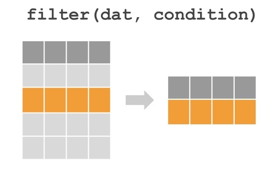

## O que é a função filter()?

**Filtrando observações (linhas) de uma data frame**

- Imagine que você tem uma planilha de vendas e quer analisar apenas as vendas:
  - de um produto específico
  - acima de determinado valor
  - em uma região específica
  - em um período específico
- A função `filter()` permite fazer essa filtragem de forma rápida e precisa

## Sintaxe da função filter()

**Sintaxe básica**

```r
# Estrutura básica
filter(df, condição)

# Com operador pipe
df %>% filter(condição)
```

- **df**: A data frame a ser filtrada
- **condição**: Expressão lógica que retorna TRUE/FALSE para cada linha
- Somente as linhas que resultam em TRUE são mantidas no resultado

## Operadores para construir condições

**Operadores na linguagem dos negócios**

| Operador | Exemplo em Linguagem Natural | Código em R |
| --- | --- | --- |
| == | Apenas os países europeus | continent == “Europe” |
| != | Todos, exceto os países europeus | continent != “Europe” |
| > | Países com PIB per capita maior que 10.000 | gdpPercap > 10000 |
| < | Países com menos de 1 milhão de habitantes | pop < 1000000 |
| >= | Países a partir do ano 2000 | year >= 2000 |
| & | Países europeus a partir de 2000 | continent == “Europe” & year >= 2000 |
| `\|` | Países da Europa ou da Ásia | continent == “Europe” \| continent == “Asia” |

## Operadores para construir condições

**Dica**

**Dica para memorizar:**

- Use == para igualdade (lembre-se: dois sinais de igual, não apenas um)
- Use & para “E” (quero este critério **E** aquele também)
- Use | para “OU” (quero este critério **OU** aquele)

## Exemplo básico

**Cenário: Análise de vendas por continente**

Imagine que a data frame `gapminder` representa dados de filiais de uma empresa multinacional:

```r
# Filtra apenas países das Américas
# como se fossem filiais da região Américas

filiais_americas <- gapminder %>%
  filter(continent == "Americas")

# Visualiza as primeiras 6 linhas do resultado
head(filiais_americas)
```

```
# A tibble: 6 × 6
  country   continent  year lifeExp      pop gdpPercap
  <fct>     <fct>     <int>   <dbl>    <int>     <dbl>
1 Argentina Americas   1952    62.5 17876956     5911.
2 Argentina Americas   1957    64.4 19610538     6857.
3 Argentina Americas   1962    65.1 21283783     7133.
4 Argentina Americas   1967    65.6 22934225     8053.
5 Argentina Americas   1972    67.1 24779799     9443.
6 Argentina Americas   1977    68.5 26983828    10079.
```

**Interpretação:** Este filtro seria equivalente a selecionar apenas dados de filiais localizadas nas Américas para uma análise regional de desempenho.

## Pensando como um Analista de Negócios

**Perguntas de negócios traduzidas para filter()**

| Pergunta de Negócio | Código com filter() |
| --- | --- |
| Quais países tiveram PIB per capita acima de $20.000 em 2007? | filter(year == 2007 & gdpPercap > 20000) |
| Quais países da Ásia tiveram expectativa de vida acima de 75 anos? | filter(continent == “Asia” & lifeExp > 75) |
| Quais países tiveram população superior a 100 milhões em 2007? | filter(year == 2007 & pop > 100000000) |
| Quais países não são da Europa nem da América? | filter(continent != “Europe” & continent != “Americas”) |

**Dica prática:** Comece sempre pensando na pergunta de negócio, depois traduza para o código

## Múltiplas condições com filter()

**Combinando condições**

Há duas maneiras principais de combinar condições:

```r
# Método 1: Usando o operador & (E lógico) - equivalente ao método 1
europeus_2007_alt <- gapminder %>%
  filter(continent == "Europe" & year == 2007)

# Método 2: Usando o operador | (OU lógico)
europa_ou_asia <- gapminder %>%
  filter(continent == "Europe" | continent == "Asia")
```

Dica importante:

- Com & (“E” lógico) ambas as condições precisam ser TRUE para que a linha seja mantida
- Com | (“OU” lógico), apenas uma das condições precisa ser TRUE

## Filtrando com operadores relacionais

**Exemplos com diferentes operadores**

```r
# Países com alta expectativa de vida (maior que 80 anos)
alta_exp_vida <- gapminder %>%
  filter(lifeExp > 80)

# Países com PIB per capita abaixo de 500 dólares
baixo_pib <- gapminder %>%
  filter(gdpPercap < 500)

# Anos diferentes de 2002
nao_2002 <- gapminder %>%
  filter(year != 2002)
```

Utilize operadores relacionais para:

- Encontrar valores acima/abaixo de limites importantes
- Excluir períodos ou categorias específicas
- Identificar casos extremos ou outliers

## Combinando filter() com outras funções

**A importância da ordem das operações**

```r
# Países europeus em 2007, mostrando apenas país e expectativa de vida
europeus_lifeExp_2007 <- gapminder %>%
  filter(continent == "Europe" & year == 2007) %>%
  select(country, lifeExp)

# Ordenando o resultado por expectativa de vida (decrescente)
europeus_lifeExp_2007_ordenado <- gapminder %>%
  filter(continent == "Europe" & year == 2007) %>%
  select(country, lifeExp) %>%
  arrange(desc(lifeExp))

head(europeus_lifeExp_2007_ordenado)
```

**Ordem correta** das operações:

1. Comece com **filter()**
2. Use **select()** depois de filter
3. Se inverter a ordem, a função filter() pode falhar se você removeu colunas necessárias

Lembre-se: primeiro **filter()**, depois **select()**!

## Erros Comuns e Como Evitá-los

| Erro | Errado | Correto |
| --- | --- | --- |
| Usar = em vez de == | filter(continent = “Europe”) | filter(continent == “Europe”) |
| Esquecer as aspas em nomes | filter(continent == Europe) | filter(continent == “Europe”) |
| Não salvar o resultado | gapminder %>% filter(year == 2007) | dados_2007 <- gapminder %>% filter(year == 2007) |

## Exemplo Completo Comum

**Países europeus com alta expectativa de vida em 2007?**

```r
# Países europeus com expectativa de vida acima de 78 anos em 2007
resultado_final <- gapminder %>%
  # Filtrar por continente, ano e expectativa de vida
  filter(continent == "Europe" & year == 2007 & lifeExp > 78) %>%
  # Selecionar variáveis de interesse
  select(country, lifeExp, gdpPercap) %>%
  # Ordenar por expectativa de vida (decrescente)
  arrange(desc(lifeExp))

# Mostrar resultados
resultado_final
```

Observe o fluxo de análise:

1. Filtramos os dados com critérios específicos
2. Selecionamos apenas as variáveis de interesse
3. Ordenamos os resultados para facilitar a interpretação
4. Todo o processo forma um “pipeline” de análise limpo e legível

## Resumo: Função filter()

**O que você precisa lembrar**

1. **Para que serve:** Selecionar apenas as linhas (observações) que atendem a determinadas condições
2. **Sintaxe básica:**

```r
dados %>% filter(condição1, condição2, ...)
```

3. **Comparações mais usadas:**
   - Igual: == (dois sinais de igual!)
   - Diferente: !=
   - Maior/Menor: >, <, >=, <=
4. **Múltiplas condições:**
   - Todas as condições (E): `filter(condição1 & condição2)`
   - Qualquer condição (OU): `filter(condição1 | condição2)`
5. **Lembre-se sempre de salvar o resultado:**

```r
nova_df <- dados %>% filter(...)
```

## Sua vez

**Exercícios Práticos**

**Nível 1: Primeiros Passos com filter()**

1. Complete o código abaixo para filtrar apenas os países das Americas no ano de 2007.

```r
paises_america_2007 <- gapminder %>%
  filter(continent == "___" & year == ___)
```

2. Filtre a data frame gapminder para mostrar apenas os dados do Brasil.

**Nível 2: Combinando Condições**

3. Crie um filtro para encontrar países que atendam a TODAS estas condições:
   - Pertencem à Ásia
   - Têm população acima de 50 milhões
   - Dados do ano 2007
4. **Desafio:** Encontre países com expectativa de vida acima de 75 anos, mas PIB per capita abaixo de 10.000 dólares em 2007.

**Dica:** Comece com um filtro simples e depois adicione condições gradualmente

## Atualizando os Repositórios

**Instruções**

1. No terminal do RStudio, verifique quais arquivos/pastas foram modificados ou criados com:

```bash
git status
```

2. Você pode adicionar todos os arquivos de uma vez com:

```bash
git add .
```

3. Execute git status novamente para confirmar que todos os arquivos foram adicionados (aparecerão em verde sob “*Changes to be committed*”):

```bash
git status
```

4. Se tudo estiver em verde, faça um commit com uma mensagem descritiva:

```bash
git commit -m "atualizacoes aula 5"
```

5. Se algum arquivo ou pasta ainda aparecer em vermelho após o segundo git status, adicione as pastas/arquivos um por um:

```bash
git add relatorios/05-relatorio/05-relatorio.qmd
```

6. Execute git status novamente e faça o commit quando todos os arquivos estiverem em verde:

```bash
git commit -m "atualizacoes aula 5"
```

7. Envie o repositório local atualizado para o GitHub:

```bash
git push origin main
```

## Referências

BROMAN, K. W.; WOO, K. H. [Data Organization in Spreadsheets](https://doi.org/10.1080/00031305.2017.1375989). **The American Statistician**, v. 72, n. 1, p. 2–10, 2018.